# Biological networks - exercise 1 solution

## Introduction to igraph

### 1:The igraph package.

```r
library(igraph)
```

In the context of graph theory, a graph is a connection of points and lines connecting a subset of them. The points of the graph are called **vertices** or **nodes**. The lines connecting the vertices of a graph are known as **edges**. The edges of graphs can be imbued with directedness. If there are arrows on one or both endpoints of the edges of a graph to indicate directedness, the graph is said to be **directed**. Otherwise, if the edges are undirected, the network is said to be **undirected**.

Each edge of a graph can also have an associated numerical value, called a **weight**. Usually, the edge weights are non-negative integers. For example, if a graph represents a road network, the weights could represent the length of each road.

### 2:Creating a network graph and visualizing it

In your exercice sheet, there is an example of a network graph. It is a weighted, undirected network. Our goal is to recreate this network as an igraph object in R. We will do that in two steps

#### a)Create a graph with the same number of nodes and the same number of edges between each of those nodes. The nodes should have the same name as in the image.

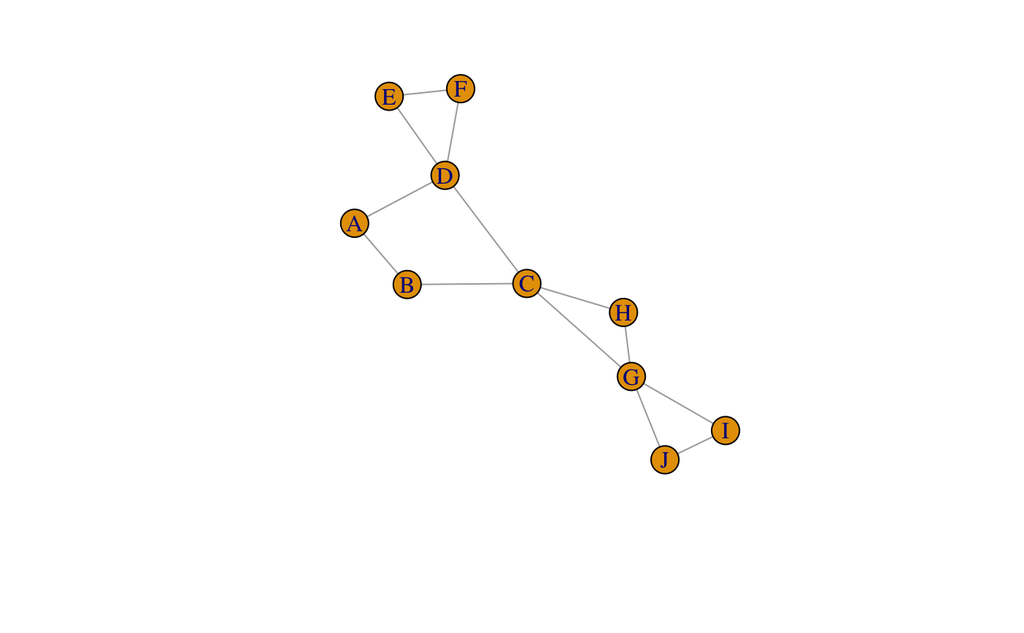

```r
mygraph <- graph(edges= c("E","F", "E","D", "F","D", "D","C", "D","A", "A","B", "B","C", "C","H", "C","G", "G","H", "G","I", "G","J", "I","J"), directed=FALSE)
plot(mygraph) #A simple graph of the network
```

```r
mygraph
```

```
IGRAPH d49cfcf UN-- 10 13 --
+ attr: name (v/c)
+ edges from d49cfcf (vertex names):
 [1] E--F E--D F--D D--C D--A A--B C--B C--H C--G H--G G--I G--J I--J
```

```r
V(mygraph)
```

```
+ 10/10 vertices, named, from d49cfcf:
 [1] E F D C A B H G I J
```

#### b)Set the weights as in the image.

```r
E(mygraph)
```

```
+ 13/13 edges from d49cfcf (vertex names):
 [1] E--F E--D F--D D--C D--A A--B C--B C--H C--G H--G G--I G--J I--J
```

```r
E(mygraph)$weight <-c(2,4,1,4,3,2,1,3,7,2,1,3,1)
E(mygraph)$weight
```

```
 [1] 2 4 1 4 3 2 1 3 7 2 1 3 1
```

Now, we can plot the graph. We want to visualize the weight of the edges. One way is to have the edge width be proportional to each edge’s weight.

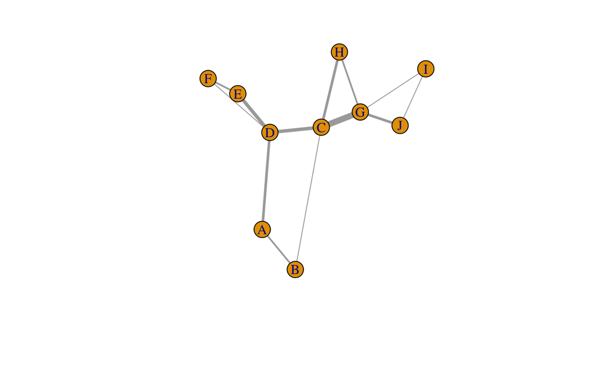

```r
plot(mygraph,edge.width=E(mygraph)$weight)
```

We can also change the place of the vertices and edges of a graph on a 2D plane or in 3D space in a way which is more visually pleasing to our eyes. There are many different layouts available in igraph. A few examples:

**Circular layout**

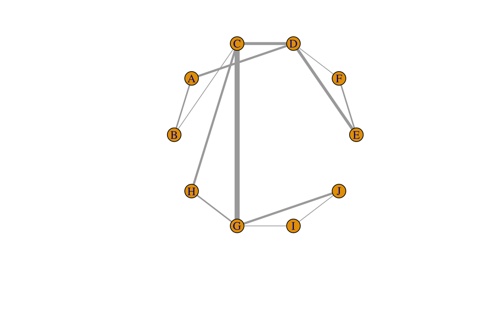

```r
plot(mygraph,edge.width=E(mygraph)$weight, layout=layout.circle)
```

This layout places the vertices uniformly in a circle

**Fruchterman-Reingold layout**

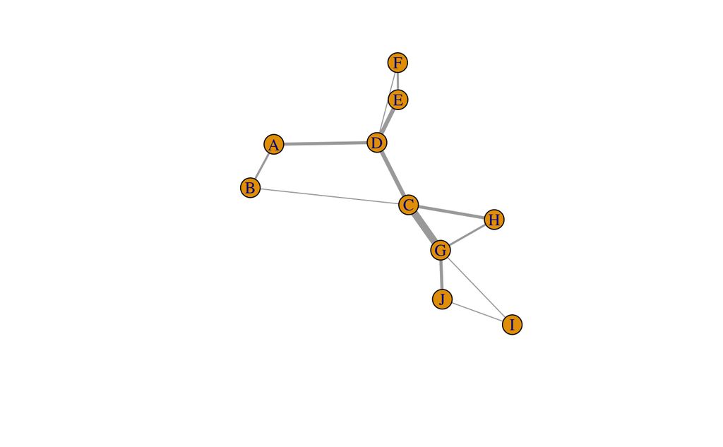

```r
plot(mygraph,edge.width=E(mygraph)$weight, layout=layout.fruchterman.reingold)
```

This is a force-directed layout, placing the vertices on a plane according to the Fruchterman-Reingold algorithm.

**Star layout**

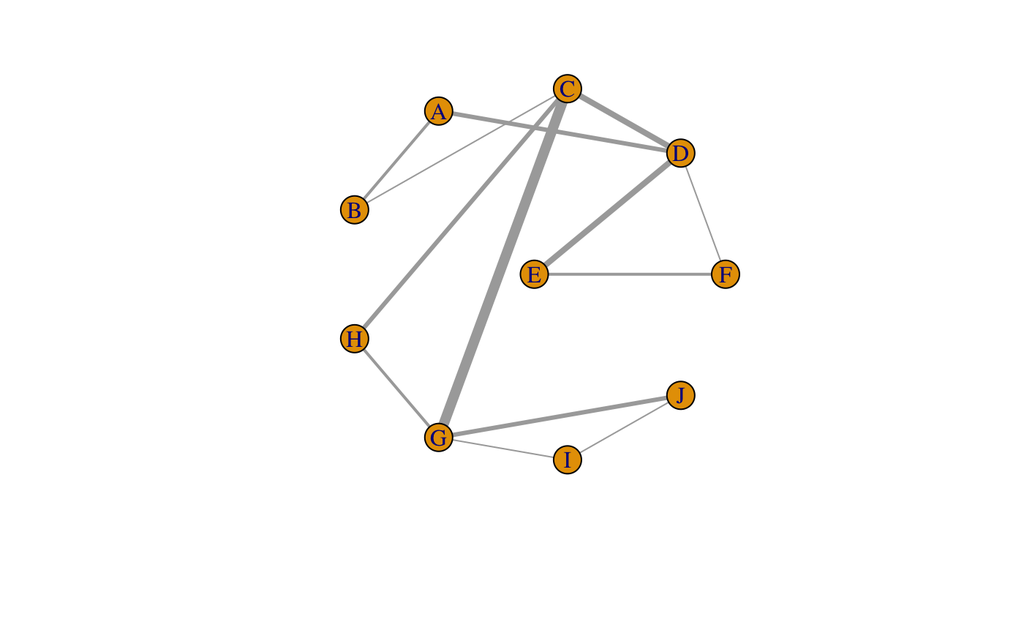

```r
plot(mygraph,edge.width=E(mygraph)$weight, layout=layout.star)
```

### 3.Vertex Degree

The **degree** of a vertex of a graph is the number of edges incident to the vertex. The igraph package has a built-in function that can calculate the degree of every vertex of the network.

```r
degree(mygraph)
```

```
E F D C A B H G I J
2 2 4 4 2 2 2 4 2 2
```

The goal is to write a function that can also do that.

```r
get_degrees = function(g) {
adj = get.adjacency(g) #Converting the graph to an adjacency matrix.
acc = rep(NA,nrow(adj))#Creating an empty vector with the same length as the number of vertices
names(acc)<-rownames(adj)#Naming the vector elements with the same names as the vertices.
for (i in 1:nrow(adj)) { #Using a for-loop
      acc[i] = sum(adj[i,])
}
return(acc)
}
get_degrees(mygraph)
```

```
E F D C A B H G I J
2 2 4 4 2 2 2 4 2 2
```

### 4.The Dijkstra algorithm

Finding the shortest path between two nodes in a graph is a common problem. It has applications ranging from biological system -studying how infectious diseases spread- to navigation to find the shortest route from one city to another. A widely used algorithm to determine the shortest path is Dijkstra. In this exercise, you have to determine the shortest path between the point E to J of the graph above. For this purpose, you will need to implement the Dijkstra algorithm.

*The implementation will be part of the homework!*

### 5.(Optional)Degree distributions of some interesting random graphs

A random graph is a graph that is obtained by randomly sampling from a collection of graphs. This collection may be characterized by certain graph parameters having fixed values.

In the Erdos-Renyi random graph model, G(n,p)is the random graph obtained by starting with vertex set V={1,2,3…n},letting 0≤p≤1, and connecting each pair vertices{i, j} by a edge with probability p.

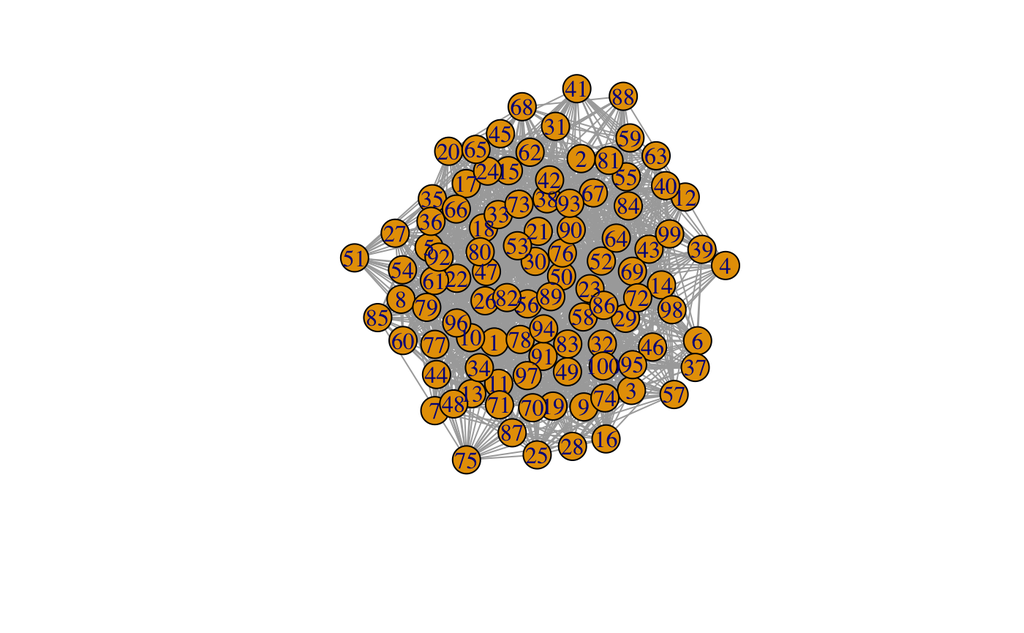

```r
erdos = erdos.renyi.game(100, p = 0.3)
plot(erdos)
```

The Barabasi-Albert model is a very simple stochastic algorithm for generating random scale-free networks using a preferential attachment mechanism.

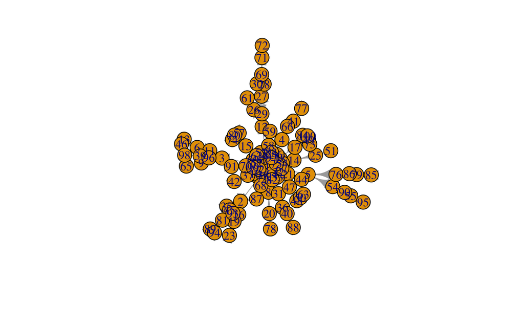

```r
barabasi = barabasi.game(100)
plot(barabasi)
```

make_lattice creates lattice graphs

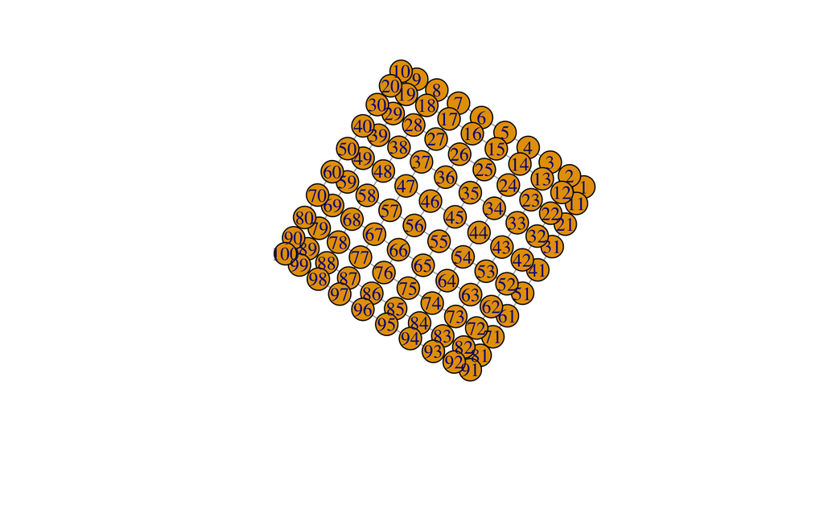

```r
lat = make_lattice(dimvector = c(10,10))
plot(lat)
```

Let’s calculate and plot their degree distributions.

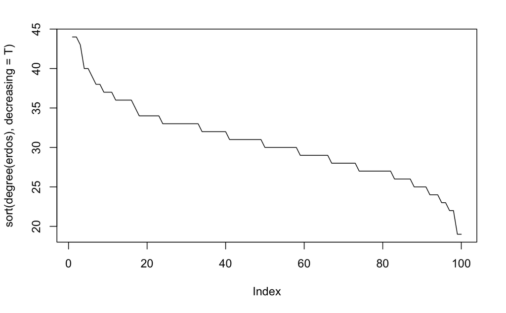

```r
  plot(sort(degree(erdos), decreasing = T), type="l")
```

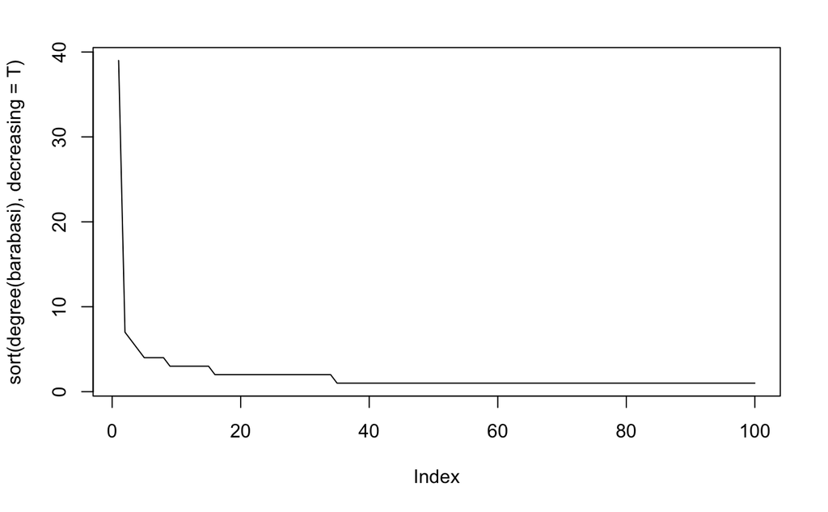

```r
  plot(sort(degree(barabasi), decreasing = T), type="l")
```

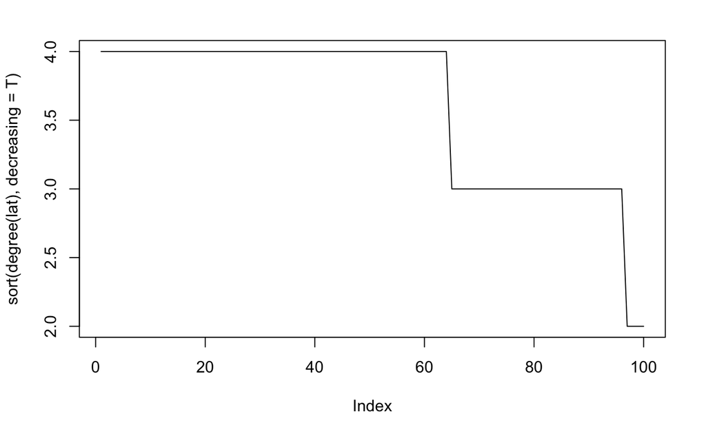

```r
  plot(sort(degree(lat), decreasing = T), type="l")
```